# Exposición individual

***Algoritmos Genéticos en Python***

**Autor:** *Jose Pablo Trejos Conejo | C07862*

Puede acceder a este [link](https://github.com/Jtrejos2901/proyecto_individual_herramientas_ii.git) para ver el repositorio con todos los archivos.

# Librería

Con el objetivo de presentar una librería que permita el uso de algoritmos genéticos para la resolución de problemas de optimización, se pretende crear una clase que implementa las funcionalidades de la librería `deap` la cual se presenta como un *framework* con multiples funciones orientadas a simplificar la codificación de algoritmos evolutivos en python. Para su instalación en *jupyter* se procede con el comando `pip install deap`, con este comando se instalará la librería que, posterior al reinicio del kernel de *Python 3*, se podrá importar.

## Detalles de la librería

Acontinuación se detalla qué funciones y objetos nos interesan de los modulos importados en la clase ya mencionada.

**I**: Del modulo `creator` nos interesará la función `create` pues esta función permite generar clases según los siguientes parámetros:

- *name*: Nombre de la clase a crear.
- *base*: Clase de la que se desea heredar.
- *attribute*: Los atributos que se le asignarán a la clase creada.

En términos generales, con el modulo `creator` y la función `create`, podemos simplificar la creación de clases.

**II**: Por otro lado del modulo `base` nos interesa acceder al objeto `base.Fitness` pues este posee los siguientes atributos de interés:

- *values*: Tupla que contiene los valores (fitness) de calidad de cada individuos (Al optimizar funciones, este atributo contiene el resultado de evaluar al infividuos en la función).
- *dominates*: Este atributo es un booleano que indica que si una solución es peor que otra. Se utiliza cuando se tiene un problema con mútiples objetivos.
- *valid*: indica si el valor (fitness) de un individuo es válido.

**III**: Finalmente, del mismo modulo `base` no interesa el objeto `base.Toolbox` pues este objeto permite registrar funciones para su llamada en diferentes secciones de código. La manera en que se registran estas funciones, es mediante el método `register` del objeto. Este método posee los siguientes parámetros.

- *alias*: Nombre con el que se registra la función (No es necesario que se el mismo que posee la función a registrar).
- *function*: Función a registrar.
- *argument*: Los argumentos que se le pasarán a la función registrada.

Una vez que se explicaron los objetos más importantes, se procede a generar el algoritmo.

# Importación de la clase

Incialmente se importa la clase `GeneticAlgorithm` desde el modulo `GenAlgorithm` y se instancia un objeto de esta clase.

```python
# Se importa la clase a utilizar.
from cod.GenAlgorithm import GeneticAlgorithm

# Se instancia un objeto de la clase
algoritmo = GeneticAlgorithm()
```

## Creación de las clases

Ahora se procede con la creación de las clases para los individuos y la población, estas clases se crean automaticamente desde el método `create` de la clase importada.

```python
algoritmo.create()
```

# Registro de funciones

Como se mencionó, el *framework* `deap` posee multiples funciones y clases que ayudan en la creación de código para la implementación de algoritmos evolutivos. De ahí que se procede al registro de funciones que serán de mucha utilidad para la implementación del algoritmo, esto se hará mediante el método `register` de la clase importada que se encarga de, como su nimbre lo indica, registrar las funciones de utilidad. Este método posee los siguientes parámetros:

- `l_min`: El menor valor con el que un gen se puede generar.
- `l_max`: El mayor valor con el que un gen se puede generar.
- `n_genom`: El número de genes que poseerá cada individuo.
- `n_pop`: El número de individuos que conformarán la población inicial.

Una vez que se conocen los parametros, se procede al registro de las funciones.

```python
algoritmo.register(-5.12, 5.12, 2, 100)
```

## Forma de los individuos

Una vez que registramos las funciones importantes, se procede a mostrar cómo se ven los individuos.

```python
algoritmo.generate_individual()
```

```
[-0.5688728267459746, 3.608935076470641]
```

## Forma de la poblacion

Ahora se pretende a mostrar el cómo se ve la población de 100 individuos.

```python
algoritmo.generate_population()
```

|  | 0 | 1 |
| --- | --- | --- |
| 0 | 3.427509 | -1.177946 |
| 1 | -1.041668 | -3.448455 |
| 2 | 0.172741 | 5.032639 |
| 3 | 3.494669 | -2.984257 |
| 4 | -1.388478 | -4.109525 |
| ... | ... | ... |
| 95 | 4.797712 | 4.795877 |
| 96 | -2.123698 | 3.730587 |
| 97 | -2.985287 | 0.068791 |
| 98 | -3.840953 | -0.794718 |
| 99 | 1.984907 | -2.490668 |

100 rows × 2 columns

# Función objetivo

Ahora que se han registrado las funciones y creado las clases importantes, se procede a mostrar el problema en custión.

Para este proyecto, se pretende mostrar el poder de estos algoritmos mediante la minimización de la función *Rastrigin*, función propuesta por un investigador con el mismo nombre en 1974 para testear algoritmos de optimización pues esta función presenta multiples minimos y maximos globales, con un mínimo global en 0.

La función se define de la siguiente forma:

$$f(x) = An + \sum_{i=1}^{n}[x_{i}^{2} - A \cos(2 \pi x_{i})]$$

Para este caso se tomará $A = 10$ y $n = 2$ para mostrar el gráfico el cual es el siguiente:

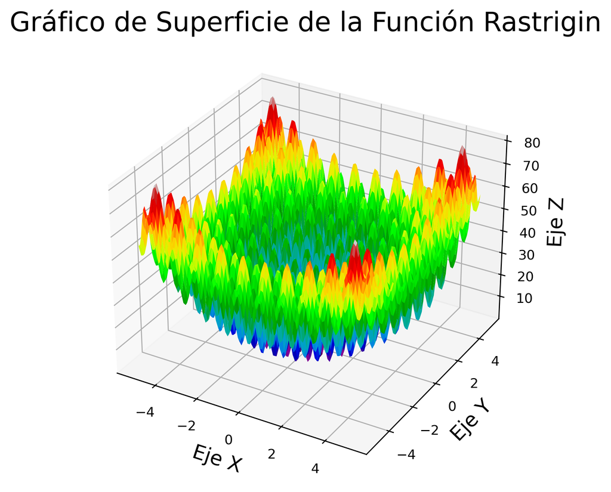

```python
algoritmo.plot_target_function()
```

# Ejecución del algoritmo

Una vez que se cuenta con todos lo necesario para ejecutar el algoritmo, se procede a ejecutar el método `execute` de la clase importada. Esta clase posee los siguientes parámetros:

- `seed`: Es la semilla que se utilizará para la reproducibilidad de los resultados.
- `CXPB`: La probabilidad de cruce para cada individuo.
- `MUTPB`: La probabilidad de mutación de cada individuo.
- `NGEN`: Número de generaciones que se generarán.

Entonces se procede con la ejecución:

```python
algoritmo.execute(2510, 0.5, 0.5, 5000)
```

# Resultados

Finalmente se procede a imprimir el resultado para el mejor individuo. Primero se mostrará el genoma del individuo:

```python
algoritmo.best_result
```

|  | x | y |
| --- | --- | --- |
| 0 | -0.000199 | 0.000264 |

Ahora el valor mínimo aproximado encontrado:

```python
algoritmo.value
```

|  | Mínimo aproximado |
| --- | --- |
| 0 | 0.000022 |

Finalmente se muestran las estadísticas de las iteraciones realizadas:

```python
algoritmo.statistics
```

|  | gen | nevals | avg | min | max |
| --- | --- | --- | --- | --- | --- |
| 0 | 0 | 100 | 35.955706 | 4.279286 | 71.426207 |
| 1 | 1 | 82 | 83.745707 | 4.457158 | 1000.000000 |
| 2 | 2 | 80 | 57.571077 | 1.974814 | 1000.000000 |
| 3 | 3 | 80 | 61.524998 | 0.524680 | 1000.000000 |
| 4 | 4 | 71 | 56.672137 | 0.524680 | 1000.000000 |
| ... | ... | ... | ... | ... | ... |
| 4996 | 4996 | 81 | 81.285116 | 0.000022 | 1000.000000 |
| 4997 | 4997 | 70 | 41.018130 | 0.000022 | 1000.000000 |
| 4998 | 4998 | 71 | 30.699204 | 0.000022 | 1000.000000 |
| 4999 | 4999 | 81 | 20.675375 | 0.000022 | 1000.000000 |
| 5000 | 5000 | 80 | 21.016045 | 0.000022 | 1000.000000 |

5001 rows × 5 columns

Como se puede ver, el mínimo obtenido es realmente muy cercano al mínimo global localizado en $(0,0)$, además, en las estadísticas se pueden ver los valores mínimos encontrados, los cuales disminuyen progresivamente hasta llegar al valor aproximado obtenido.